# (Dataset Exploration Title)

### Discuss the distribution(s) of your variable(s) of interest. Were there any unusual points? Did you need to perform any transformations?

> The trip duration variable took on a large range of values, so I looked at the data using a log transform. Under the transformation, the data looked bell-shaped, with most durations are around 500 seconds (about 8 minutes).

## Bivariate Exploration

> First and foremost, I would like to plot the map of stations given their geo-locations.

```python
#If we check the outer join dataframe above, we can see there is not any nulls:
print(df_bike_inflow_outflow.isnull().sum())
```

```
station_id          0
bike_outflows       0
bike_inflows        0
net_bike_inflows    0
dtype: int64
```

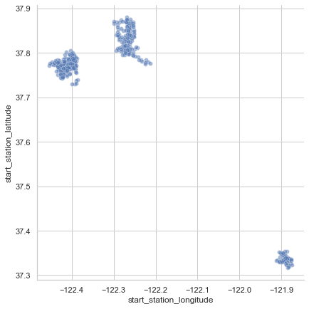

```python
#So the start_sation_id column gives all the station ids in out dataset. From that we derive the geopositions of the stations:

df_geo_locations = df[['start_station_id', 'start_station_latitude', 'start_station_longitude']].drop_duplicates()
df_geo_locations.reset_index(inplace=True, drop=True)
df_geo_locations = df_geo_locations[df_geo_locations.start_station_id !=0]

sb.relplot(x="start_station_longitude", y="start_station_latitude",
            sizes=(40, 400), alpha=.5, palette="muted",
            height=6, data=df_geo_locations)
plt.show()
```

```python
df_geo_locations
```

|  | start_station_id | start_station_latitude | start_station_longitude |
| --- | --- | --- | --- |
| 0 | 21 | 37.789625 | -122.400811 |
| 1 | 23 | 37.791464 | -122.391034 |
| 2 | 86 | 37.769305 | -122.426826 |
| 3 | 375 | 37.774836 | -122.446546 |
| 4 | 7 | 37.804562 | -122.271738 |
| ... | ... | ... | ... |
| 331 | 301 | 37.318450 | -121.883172 |
| 332 | 226 | 37.781123 | -122.232991 |
| 333 | 234 | 37.778058 | -122.225400 |
| 339 | 224 | 37.784855 | -122.239305 |
| 342 | 37 | 37.785000 | -122.395936 |

329 rows × 3 columns

> Just looking at the picture above, we can say that stations' locations are packed in three major areas with the two biggest relatively closer to each other.

```
   start_station_id  end_station_id  flow_numbers
0                81              15           337
1                15               6           314
2               196             182           310
3                 6              16           285
4               182             196           284
```

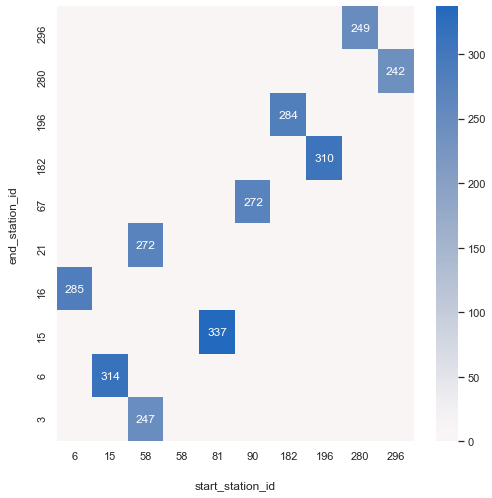

```python
# Find the top 10 journeys lended bike numbers of which are highest for the whole period and plot a heatmap:
df_trip_flows = df[['start_station_id', 'end_station_id', 'end_station_name']].groupby(['start_station_id', 'end_station_id']).count()
df_trip_flows = df_trip_flows.reset_index().sort_values(by='end_station_name', ascending=False)
df_trip_flows.rename(columns={'end_station_name':'flow_numbers'}, inplace=True)
df_trip_flows.reset_index(drop=True, inplace=True)
df_trip_flows.drop_duplicates(subset=['start_station_id', 'end_station_id'], inplace=True)
print(df_trip_flows.head())

columns = df_trip_flows.start_station_id.head(10)#.unique()
index = df_trip_flows.end_station_id.head(10)#.unique()
df_bike_outflows = pd.DataFrame(index=np.sort(index), columns=np.sort(columns))
df_bike_outflows

for i in df_bike_outflows.columns:
    for j in df_bike_outflows.index:
        try:
            value = df_trip_flows.head(10)[(df_trip_flows.head(10).start_station_id == i)&\
                                           (df_trip_flows.head(10).end_station_id == j)].iloc[0, 2]
        except:
            value = np.nan
        try:
            x = len(df_bike_outflows.loc[j, i])
            if x > 1:
                df_bike_outflows.loc[j, i] = [value] + (x-1)*[np.nan]
        except:
            df_bike_outflows.loc[j, i] = value

df_bike_outflows.fillna(0, inplace=True)
df_bike_outflows = df_bike_outflows.applymap(int)
df_bike_outflows.sort_index(inplace=True, ascending=False)

def label(x):
    if x == 0:
        return ''
    else:
        return x
labels = df_bike_outflows.applymap(label)
plt.figure(figsize = [8, 8])
sb.heatmap(df_bike_outflows, annot = labels, fmt = '',
           cmap = 'vlag_r', center = 0)
plt.xlabel('start_station_id', labelpad=20)
plt.ylabel('end_station_id', labelpad=20)
plt.show()
```

> From the picture above, we it could be concluded that the most bike trips (337) occured from the station 81 to the station 15.

> Does overall duration of incoming bike trips per station vary? For answering this question, first, we calculate overall incoming bike trip durations per station and sort them and plot a barplot.

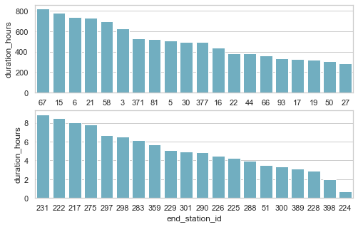

```python
df_overall_duration = df[['end_station_id', 'duration_sec']].groupby('end_station_id').sum().reset_index()
df_overall_duration.sort_values(by='duration_sec', ascending=False, inplace=True)
df_overall_duration.reset_index(drop=True, inplace=True)
df_overall_duration['duration_sec'] = df_overall_duration['duration_sec'].apply(lambda x: x/3600)
df_overall_duration.rename(columns={'duration_sec':'duration_hours'}, inplace=True)
data1 = df_overall_duration.head(20)
data2 = df_overall_duration.tail(20)
default_color = sb.color_palette()[9]
#sb.set(rc = {'figure.figsize':(10,5)})
fig, ax = plt.subplots(nrows=2, figsize = [8,5])
sb.barplot(x="end_station_id", y="duration_hours", data=data1, ax=ax[0], order=data1['end_station_id'], color=default_color)
sb.barplot(x="end_station_id", y="duration_hours", data=data2, ax=ax[1], order=data2['end_station_id'], color=default_color)
plt.show()
```

> From that picture, we can say that the stations 67, 15, 6, 21 and 58 are the top 5 stations that received longest trips while the stations 224, 398, 228, 389 and 300 are the ones that received shortest trips.

> If we see overall durations per gender and user type, we will use the following code:

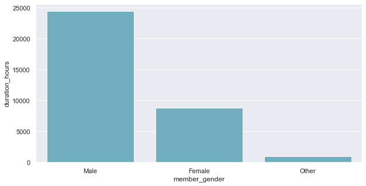

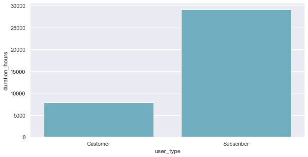

```python
df_overall_duration_per_gender = df[['member_gender', 'duration_sec']].groupby('member_gender').sum().reset_index()
df_overall_duration_per_gender.sort_values(by='duration_sec', ascending=False, inplace=True)
df_overall_duration_per_gender.reset_index(drop=True, inplace=True)
df_overall_duration_per_gender['duration_sec'] = df_overall_duration_per_gender['duration_sec'].apply(lambda x: x/3600)
df_overall_duration_per_gender.rename(columns={'duration_sec':'duration_hours'}, inplace=True)
data =df_overall_duration_per_gender

default_color = sb.color_palette()[9]
sb.set(rc = {'figure.figsize':(10,5)})
sb.barplot(x="member_gender", y="duration_hours", data=data, color=default_color)
plt.show()

df_overall_duration_user_type = df[['user_type', 'duration_sec']].groupby('user_type').sum().reset_index()
df_overall_duration_user_type.sort_values(by='duration_sec', ascending=False, inplace=True)
df_overall_duration_user_type.reset_index(drop=True, inplace=True)
df_overall_duration_user_type['duration_sec'] = df_overall_duration_user_type['duration_sec'].apply(lambda x: x/3600)
df_overall_duration_user_type.rename(columns={'duration_sec':'duration_hours'}, inplace=True)
data =df_overall_duration_user_type

default_color = sb.color_palette()[9]
sb.set(rc = {'figure.figsize':(10,5)})
sb.barplot(x="user_type", y="duration_hours", data=data, color=default_color)
plt.show()
```

> As expected males experieced the most overall duration for the whole period. And Subscribers are almost 4 times far more solid reasons for the deterioration of the bikes.

> If we see overall durations per age group, we will use the following code:

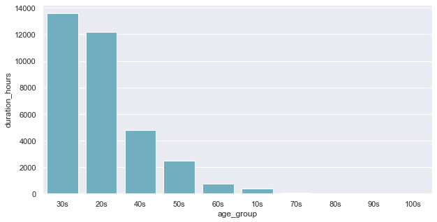

```python
# calculate overall durations per age group
df_overall_duration_per_agegroup = df[['age_group', 'duration_sec']].groupby('age_group').sum().reset_index()
df_overall_duration_per_agegroup.sort_values(by='duration_sec', ascending=False, inplace=True)
df_overall_duration_per_agegroup.reset_index(drop=True, inplace=True)
df_overall_duration_per_agegroup['duration_sec'] = df_overall_duration_per_agegroup['duration_sec'].apply(lambda x: x/3600)
df_overall_duration_per_agegroup.rename(columns={'duration_sec':'duration_hours'}, inplace=True)
data =df_overall_duration_per_agegroup

default_color = sb.color_palette()[9]
sb.set(rc = {'figure.figsize':(10,5)})
sb.barplot(x="age_group", y="duration_hours", data=data, color=default_color)
plt.show()
```

```python
#building a dataframe from the dataset, which contains age groups and average bike trip duration per user in age groups.
df_overall_duration_per_agegroup = df_overall_duration_per_agegroup\
.join(pd.DataFrame(df_age_groups), on='age_group', rsuffix='_number')
df_overall_duration_per_agegroup['average_min_per_user'] = df_overall_duration_per_agegroup.duration_hours*60/\
df_overall_duration_per_agegroup.age_group_number
df_overall_duration_per_agegroup
```

|  | age_group | duration_hours | age_group_number | average_min_per_user |
| --- | --- | --- | --- | --- |
| 0 | 30s | 13573.238056 | 69102 | 11.785394 |
| 1 | 20s | 12158.859722 | 63671 | 11.457831 |
| 2 | 40s | 4804.678056 | 24392 | 11.818657 |
| 3 | 50s | 2469.279444 | 12116 | 12.228191 |
| 4 | 60s | 737.181944 | 3480 | 12.710034 |
| 5 | 10s | 398.490556 | 1712 | 13.965790 |
| 6 | 70s | 94.306389 | 471 | 12.013553 |
| 7 | 80s | 11.410833 | 126 | 5.433730 |
| 8 | 90s | 0.703333 | 5 | 8.440000 |
| 9 | 100s | 0.201944 | 1 | 12.116667 |

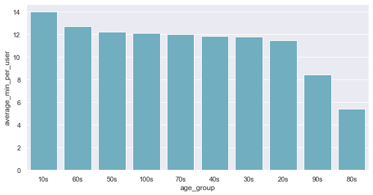

```python
# calculate avarage durations per age group:
data = df_overall_duration_per_agegroup.sort_values(by='average_min_per_user', ascending=False)
default_color = sb.color_palette()[9]
sb.set(rc = {'figure.figsize':(10,5)})
sb.barplot(x="age_group", y="average_min_per_user", data=data, color=default_color)
plt.show()
```

> Furthermore, we will look at that on which days of the period the company experienced the longest overall durations of lended bike trips.

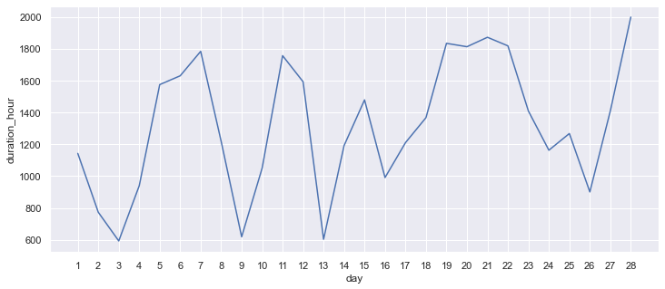

```python
# calculate overall durations of lended bikes per day:
df['day'] = df.end_time.dt.day
df['day_of_week'] = df.end_time.dt.day_name()
df_duration_per_day = df[['day', 'day_of_week', 'duration_sec']].groupby(['day', 'day_of_week']).sum().reset_index()
df_duration_per_day['duration_hour'] = df_duration_per_day['duration_sec'].apply(lambda x: x/3600)
df_duration_per_day

sb.set(rc = {'figure.figsize':(12,5)})
g = sb.lineplot(x="day", y="duration_hour", data=df_duration_per_day)
plt.xticks(df_duration_per_day.day)

plt.show()
```

> From that picture we can say that overall trip durations per day fluctuated and peaked at the end of the period.

### Did you observe any interesting relationships between the other features (not the main feature(s) of interest)?

> Interestingly, the overall volume of bike trip durations peaked at the end of the month, which is crucial for resource planning orientation!

## Multivariate Exploration

```python
df_overall_duration = df[['end_station_id', 'duration_sec']].groupby('end_station_id').sum().reset_index()
df_overall_duration.join(df_geo_locations.set_index('start_station_id'), on='end_station_id')
```

|  | end_station_id | duration_sec | start_station_latitude | start_station_longitude |
| --- | --- | --- | --- | --- |
| 0 | 0 | 175360 | NaN | NaN |
| 1 | 3 | 2261618 | 37.786375 | -122.404904 |
| 2 | 4 | 532606 | 37.785881 | -122.408915 |
| 3 | 5 | 1840768 | 37.783899 | -122.408445 |
| 4 | 6 | 2651098 | 37.804770 | -122.403234 |
| ... | ... | ... | ... | ... |
| 325 | 385 | 211004 | 37.850578 | -122.278175 |
| 326 | 386 | 317440 | 37.752105 | -122.419724 |
| 327 | 388 | 38430 | 37.352887 | -121.886050 |
| 328 | 389 | 11223 | 37.353062 | -121.891937 |
| 329 | 398 | 7303 | 37.796471 | -122.416858 |

330 rows × 4 columns

```python
df.columns
```

```
Index(['duration_sec', 'start_time', 'end_time', 'start_station_id',
       'start_station_name', 'start_station_latitude',
       'start_station_longitude', 'end_station_id', 'end_station_name',
       'end_station_latitude', 'end_station_longitude', 'bike_id', 'user_type',
       'member_birth_year', 'member_gender', 'bike_share_for_all_trip',
       'dayhour', 'weekday', 'age_group', 'day', 'day_of_week'],
      dtype='object')
```

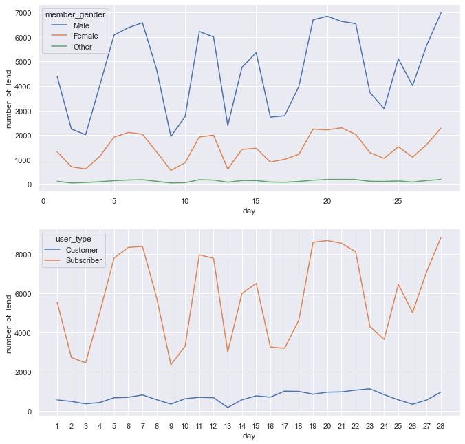

```python
df_day_gender_trip_n = df[['day', 'member_gender', 'start_station_id']].groupby(['day', 'member_gender']).count()
df_day_gender_trip_n = df_day_gender_trip_n.reset_index()
df_day_gender_trip_n.rename(columns={'start_station_id':'number_of_lend'}, inplace=True)

df_day_user_trip_n = df[['day', 'user_type', 'start_station_id']].groupby(['day', 'user_type']).count()
df_day_user_trip_n = df_day_user_trip_n.reset_index()
df_day_user_trip_n.rename(columns={'start_station_id':'number_of_lend'}, inplace=True)

fig, ax = plt.subplots(nrows=2, figsize = [11,11])

sb.lineplot(x="day", y="number_of_lend", hue="member_gender", ax=ax[0], data=df_day_gender_trip_n)
plt.xticks(df_day_gender_trip_n.day.unique())
sb.lineplot(x="day", y="number_of_lend", hue="user_type", ax=ax[1], data=df_day_user_trip_n)
plt.xticks(df_day_user_trip_n.day.unique())
plt.show()
```

From this lineplots, we can say that lended bike numbers per gender fluctuates across the days of the period, but this fluction is far stronger among male clients than females. And as for user types, subscriber's dayly visit numbers are much higher and its fluctuation is bumpier than "customers".

> When we did bivariate exploration, we found that the stations are located cluster-like in three major areas. Now we will name the most north-western one, the most north-eastern one and the most south-eastern one A, B and C areas respectively. Accordingly, we will analyse end-of-the-period shortages and abundances of bikes and compare them on the map.

```python
# identifying the statuse of each station
df_map = df_bike_inflow_outflow.join(df_geo_locations.set_index('start_station_id'), on='station_id')
df_map = df_map[df_map.station_id != 0]
def status(x):
    if x > 0:
        return 'excess'
    elif x < 0:
        return 'shortage'
    else:
        return 'balanced'

df_map['station_status'] = df_map['net_bike_inflows'].apply(status)
df_map['net_bike_inflows'] = df_map['net_bike_inflows'].apply(abs)
print(df_map.head())
```

```
   station_id  bike_outflows  bike_inflows  net_bike_inflows  \
1           3           2760          2997               237
2           4            610           609                 1
3           5           2327          2353                26
4           6           2082          2512               430
5           7            827           778                49

   start_station_latitude  start_station_longitude station_status
1               37.786375              -122.404904         excess
2               37.785881              -122.408915       shortage
3               37.783899              -122.408445         excess
4               37.804770              -122.403234         excess
5               37.804562              -122.271738       shortage
```

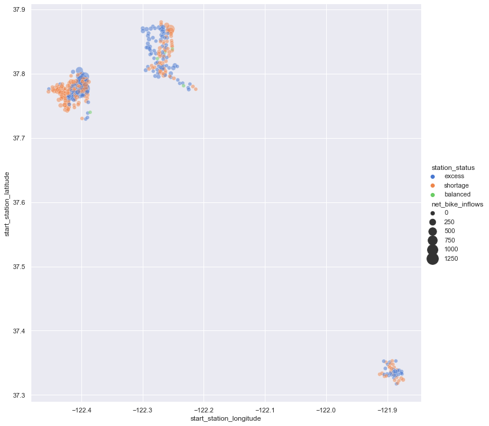

```python
sb.set(rc = {'figure.figsize':(100,100)})
sb.relplot(x="start_station_longitude", y="start_station_latitude", hue="station_status", size="net_bike_inflows",
            sizes=(40, 400), alpha=.5, palette="muted",
            height=10, data=df_map)
plt.show()
```

> Just looking at the picture above, we can say in all areas overall shortages and ubundancies of bikes are fairly balanced. Transportation can be done inside each area. So let's zoom in to look at from which station to which station bikes should be transported:

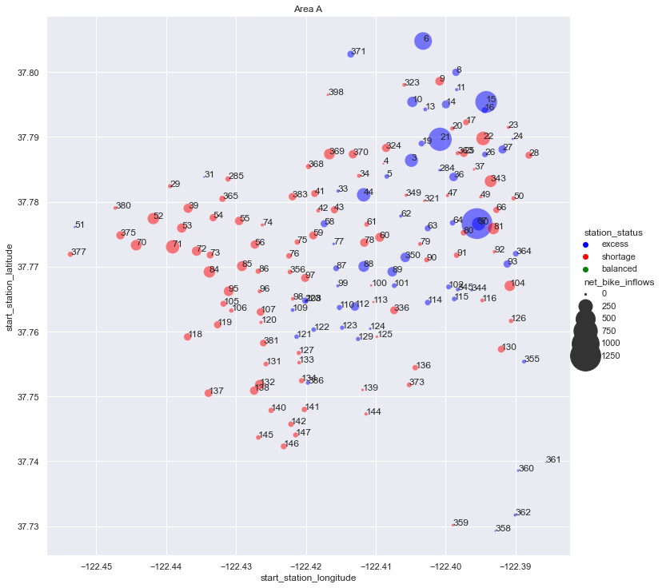

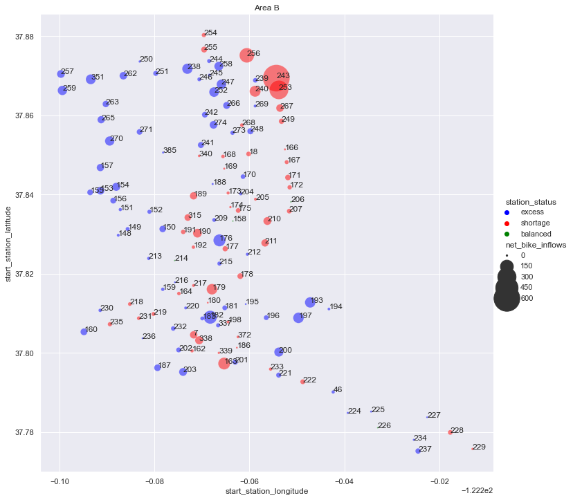

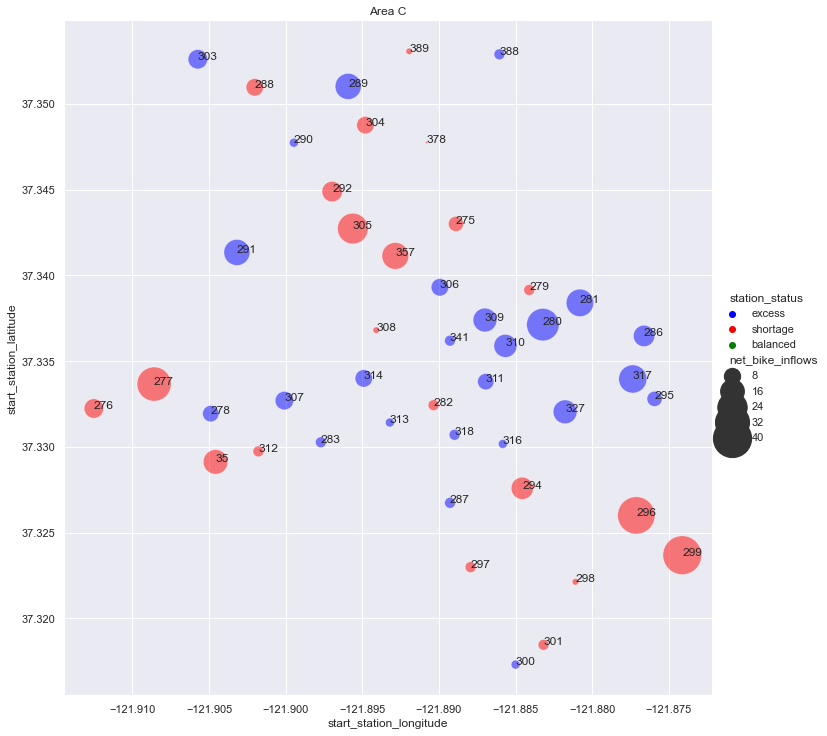

```python
df_map_A = df_map[df_map.start_station_longitude < -122.35]
df_map_B = df_map[(df_map.start_station_longitude > -122.35)&(df_map.start_station_longitude < -122.2)]
df_map_C = df_map[df_map.start_station_longitude > -122.0]

def label_point(x, y, val, ax):
    a = pd.concat({'x': x, 'y': y, 'val': val}, axis=1)
    for i, point in a.iterrows():
        ax.text(point['x'], point['y'], int(point['val']))

hue_order = ["excess", "shortage", "balanced"]
ax = sb.set(rc = {'figure.figsize':(100,100)})
sb.relplot(x="start_station_longitude", y="start_station_latitude", hue="station_status", hue_order=hue_order,\
           size="net_bike_inflows",
            sizes=(5, 1500), alpha=.5, palette=['blue', 'red', 'green'],
            height=10, data=df_map_A)

label_point(df_map_A.start_station_longitude, df_map_A.start_station_latitude, df_map_A.station_id, plt.gca())
plt.title('Area A')
plt.show()

ax = sb.set(rc = {'figure.figsize':(100,100)})
sb.relplot(x="start_station_longitude", y="start_station_latitude", hue="station_status", hue_order=hue_order,\
           size="net_bike_inflows",
            sizes=(5, 1500), alpha=.5, palette=['blue', 'red', 'green'],
            height=10, data=df_map_B)

label_point(df_map_B.start_station_longitude, df_map_B.start_station_latitude, df_map_B.station_id, plt.gca())
plt.title('Area B')
plt.show()

ax = sb.set(rc = {'figure.figsize':(100,100)})
sb.relplot(x="start_station_longitude", y="start_station_latitude", hue="station_status", hue_order=hue_order,\
           size="net_bike_inflows",
            sizes=(5, 1500), alpha=.5, palette=['blue', 'red', 'green'],
            height=10, data=df_map_C)

label_point(df_map_C.start_station_longitude, df_map_C.start_station_latitude, df_map_C.station_id, plt.gca())
plt.title('Area C')
plt.show()
```

### Talk about some of the relationships you observed in this part of the investigation. Were there features that strengthened each other in terms of looking at your feature(s) of interest?

> In order to create dateframes we use for our analysis, we have done too much joining actions!

### Were there any interesting or surprising interactions between features?

> Interestingly, when we look at the goe-locations of the stations, we can see they are located in three areas!